# 相關、迴歸與結果解讀

Week 07 Part 1

HT3001B 生物統計學與 R

2026-10-22

## 回顧 Week 6 的三個結果

| Week 6 Part 1 的結果 | 本段要解釋 |
| --- | --- |
| 年齡 Pearson 0.694，交換兩者不變 | z 分數（z-score）乘積與對稱性 |
| 正向斜率 0.279、反向斜率 1.076 | 預測誰，就最小化誰的誤差 |
| 全部 R² 0.300、37 週以上 0.035 | 基準變異、研究對象與範圍 |

- 用助學金與 Apgar 的例子，釐清相關係數、斜率與 R² 各自回答什麼問題。解讀數字時，也要看圖形、資料範圍與研究對象。

births14；IMS 2e §7.1–7.2；Rosner 8e §11.12

## 只問是否一起變動：夫妻膽固醇

- 100 對沒有血緣關係的夫妻，各量一次血清膽固醇。
- 研究問題：**夫妻的膽固醇是否有關？**

| 要保留什麼？ | 這個問題的答案 |
| --- | --- |
| 每筆配對 | 同一對夫妻的兩個測量值 |
| 兩人的角色 | 對等；交換兩者，關聯摘要不變 |
| 主要數字 | 無單位的相關係數，描述方向與強度 |

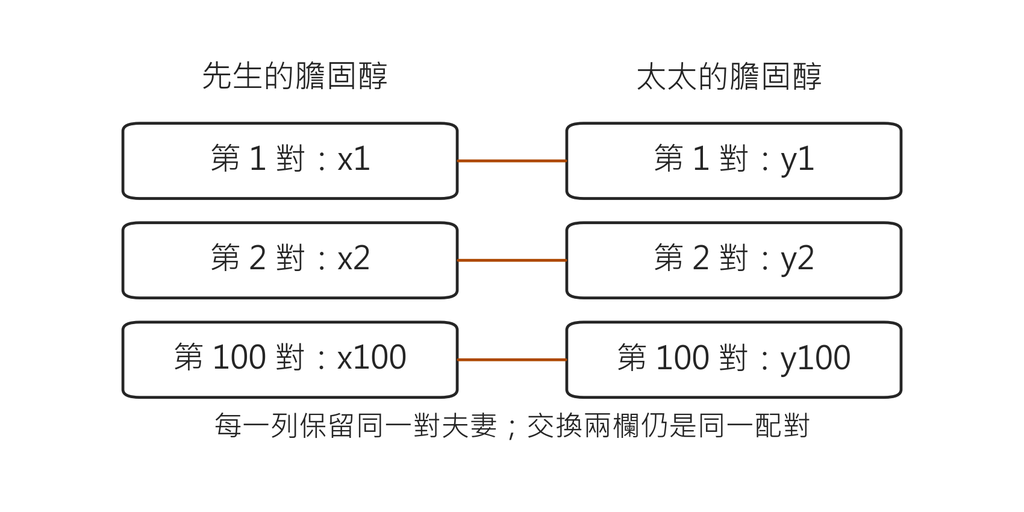

每一列連接同一對夫妻的兩個測量值；圖中沒有實際膽固醇數值。

- 夫妻膽固醇呈現相關，可能有哪些原因？

Rosner 8e §11.7，Example 11.26

## 要預測平均多少：家庭收入與助學金

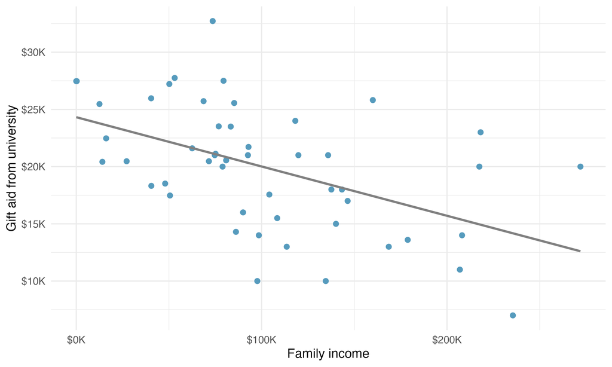

橫軸家庭收入、縱軸助學金，均以千美元為單位；每點是一名學生。

- 50 名一年級學生：知道家庭收入，想預測平均助學金多少。助學金是結果，收入是解釋變項（explanatory variable）。

IMS 2e §7.2.1，Figure 7.13（CC BY-SA）

## 相關與迴歸的差別

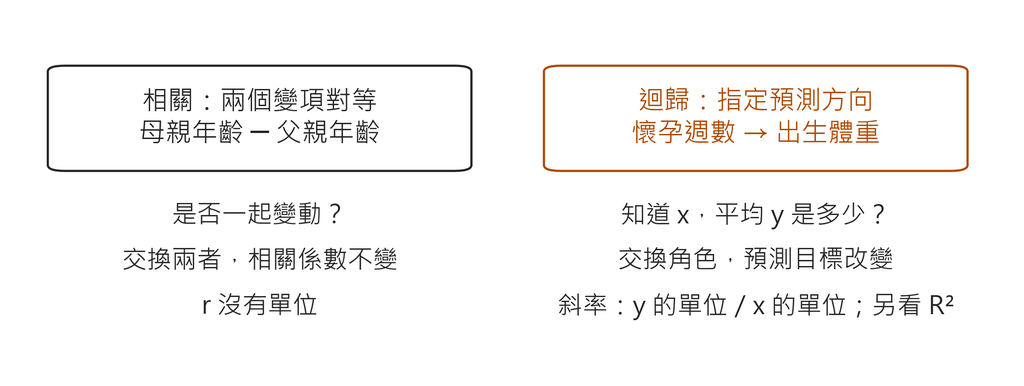

左邊比較共同變動，右邊指定預測方向；同一批資料可以回答不同問題。

- 相關問「兩個變項是否一起變動」；迴歸問「知道 x，y 的平均預測是多少」。同一份資料可以回答這兩種問題，但兩種答案不能混用。

IMS 2e §7.1–7.2；Rosner 8e §11.7

## 讀散布圖（scatterplot）：四件事

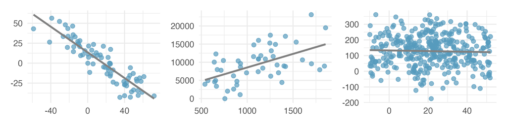

由左至右比較方向與貼線程度；先看形狀，再看散布。

1. **方向**：右上或右下
2. **形式**：直線或彎曲
3. **強度**：貼近一條線或散開
4. **異常點**：遠離點雲、分群
- 「關係多強」與「是否適合直線」分開看。先判斷形式，再決定數字能摘要什麼。

IMS 2e §7.1.1，Figure 7.2（CC BY-SA）

## 關係清楚，但不是直線

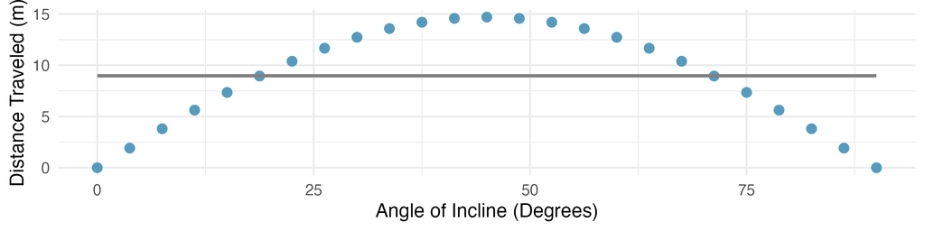

點沿曲線分布；接近水平的直線沒有保留先升後降的型態。

- 點沿曲線分布，水平直線卻給出近乎固定的預測。算得出最佳直線，不代表直線適合描述這份資料。

IMS 2e §7.1.1，Figure 7.3（CC BY-SA）

## 練習｜描述負鼠的散布圖

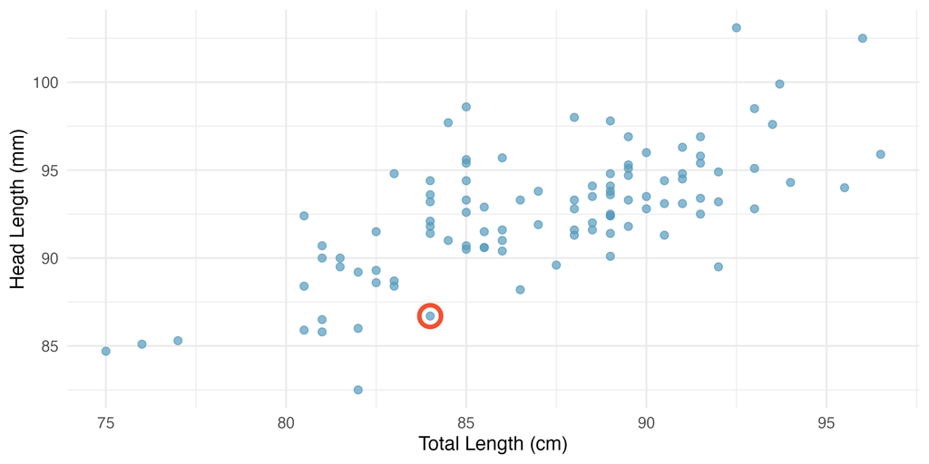

橫軸總長（cm）、縱軸頭長（mm）；每點是一隻負鼠。

- 用方向、形式、強度、異常點描述這張圖。
- 正向；大致線性但不完美；中等強度；沒有明顯遠離點雲的點。總長較長的負鼠，頭長也傾向較長。

IMS 2e §7.1.2，Figure 7.5（CC BY-SA）

## 為何先減平均，再除以 SD？

| 步驟 | 留下什麼資訊？ |
| --- | --- |
| 原始 x、y | 受各自平均值與單位影響 |
| 減各自平均 | 相對這批資料，偏高還是偏低 |
| 除各自 SD | 以各自 SD 為單位，比較偏離 |

$$z_x=\frac{x-\bar x}{s_x},\qquad z_y=\frac{y-\bar y}{s_y}$$

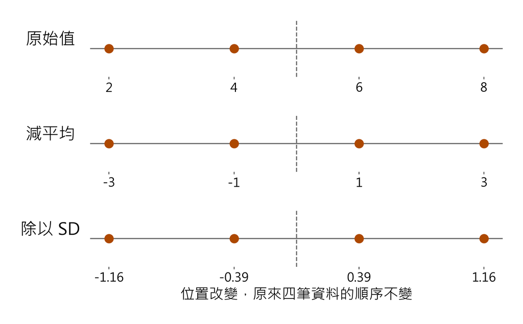

示意值 2、4、6、8 先移到平均 0，再以樣本 SD 縮放；每點仍是原來同一筆。

- 兩變項的 SD 都大於 0，才能標準化。x、y 都高於或都低於各自平均時，z 分數乘積為正；一高一低時，乘積為負。

IMS 2e §7.1.4

## 把散布圖轉成數字：Pearson r

$$z_{x,i} = \frac{x_i - \bar x}{s_x}, \qquad z_{y,i} = \frac{y_i - \bar y}{s_y}$$

$$r = \frac{1}{n-1}\sum_{i=1}^{n} z_{x,i}\, z_{y,i}$$

- 共變異數（covariance）保留兩種單位；除以兩個 SD 後得到無單位的 r。
- n − 1 與樣本 SD 的定義一致；這不是通常除以 n 的算術平均。

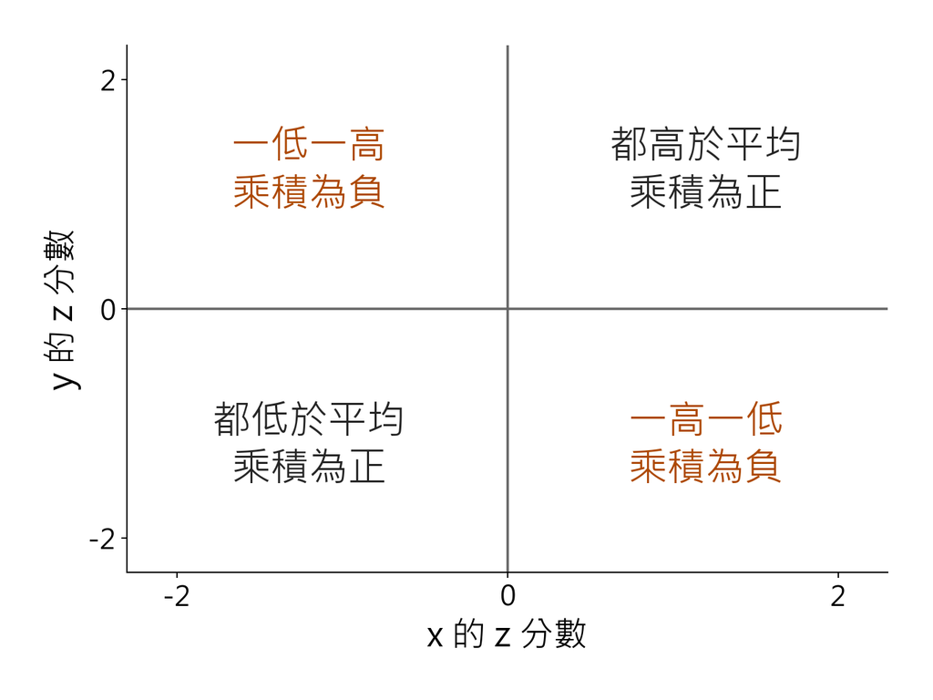

同號象限的乘積為正，異號象限為負；這張圖只表示正負，不表示人數。

IMS 2e §7.1.4；Rosner 8e Definition 11.15–11.16

## 正負還要看乘積的大小

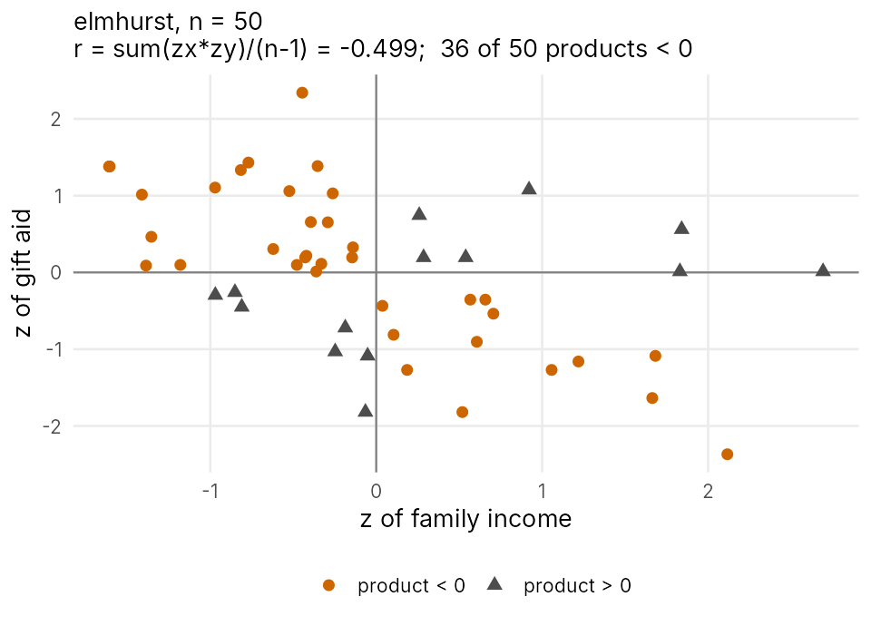

橫軸與縱軸都改為 z 分數；橘點位於一高一低的兩個象限。

- r 是每筆兩個 z 分數的乘積加總，再除以 n − 1。這份資料的負乘積總量較大，所以 r = −0.499；象限人數本身不能決定 r。

openintro elmhurst；IMS 2e §7.2.1

## r 的範圍與方向

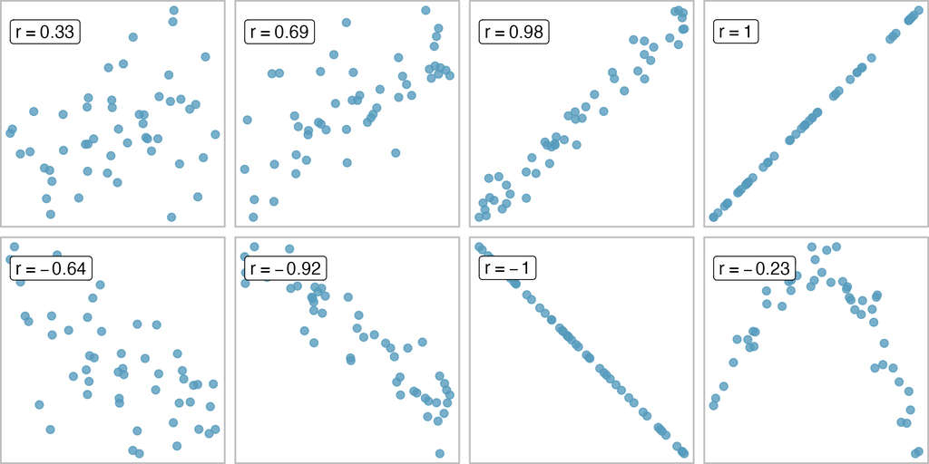

上排為正相關、下排為負相關；看點是否貼近直線。

- −1 ≤ r ≤ 1。所有點都落在同一條上升直線時，r = 1；落在同一條下降直線時，r = −1。

IMS 2e §7.1.4，Figure 7.10（CC BY-SA）

## 練習｜四張圖，配對四個 r

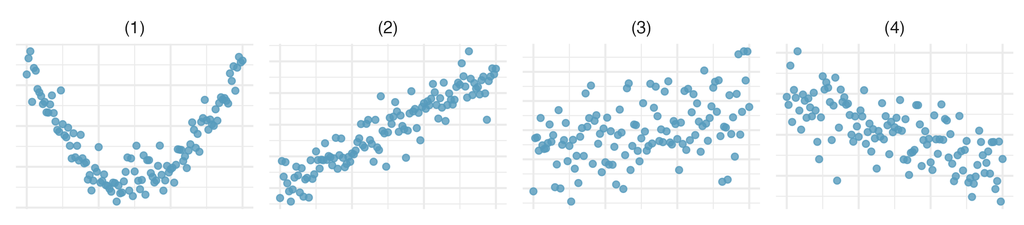

圖（1）至（4）由左至右；先判斷形狀與方向，再配對 r。

- 將 −0.70、0.45、0.06、0.92 配到圖（1）–（4）。哪張圖有明顯關係，卻最不適合只看 r？
- （1）**0.06**；（2）**0.92**；（3）**0.45**；（4）**−0.70**。
- 先看方向，再看是否貼近直線。**（1）的 U 形**很清楚，近零 r 卻沒有保留這個形狀。

IMS 2e §7.5，Exercise 7.7 a–d；Appendix A.7（CC BY-SA）

## 換單位，r 不變

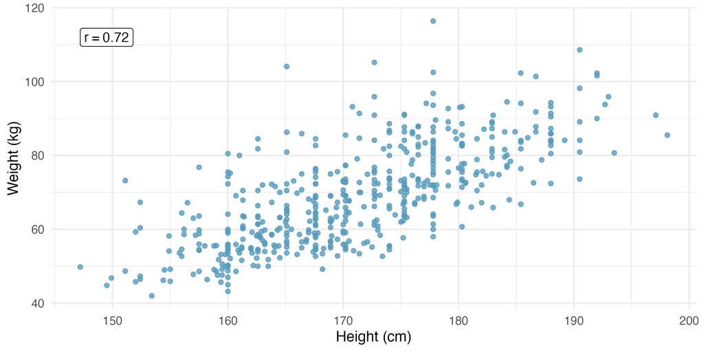

同一批成人：橫軸身高（cm），縱軸體重（kg）。

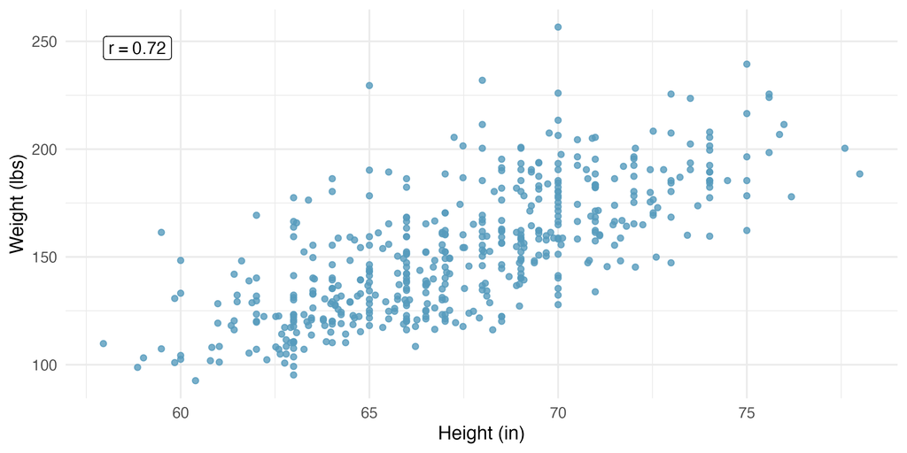

只換單位：橫軸身高（in），縱軸體重（lb），點的配對不變。

- 乘上正數，平均與 SD 同倍改變；加上常數，在減平均時消去。z 分數不變，r 不變（重算：0.717）。

IMS 2e §7.1.4，Figure 7.12a–b（CC BY-SA）；openintro bdims

## 練習｜換溫度與年齡的單位

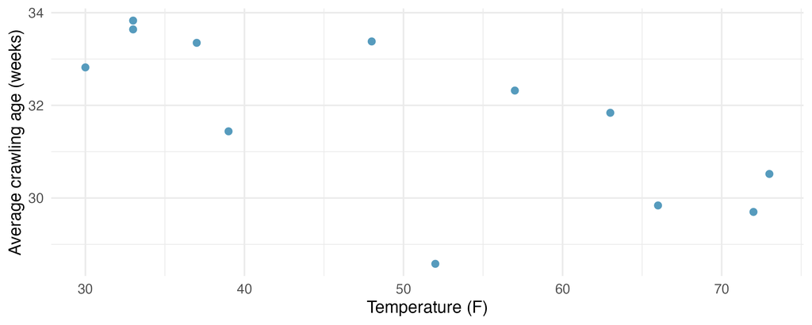

橫軸華氏溫度、縱軸平均爬行年齡（週）；每點是一個出生月份群體。

- 每點是**一個出生月份群體**的平均，不是單一嬰兒。原單位為華氏、週，r = −0.70。
- 描述關係。改成攝氏、月後，r 和散布圖的方向、形式、強度會改變嗎？
- 大致負向、近似線性，有散布。
- **r 仍為 −0.70**：華氏轉攝氏的平移在減平均時消去，正乘數被 SD 抵銷；改用月也不反轉次序。

IMS 2e §7.5，Exercise 7.12 a–c（Crawling babies, correlation；CC BY-SA）

## r 只量線性關係

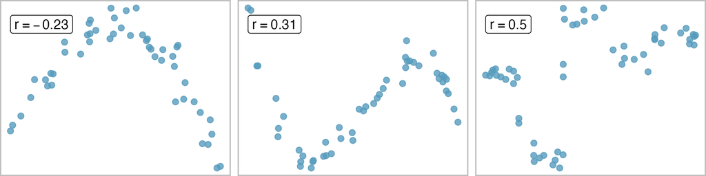

三圖都有彎曲型態；單一 r 沒有保留完整的資料形狀。

- 點即使緊貼曲線，r 也可能只有中等或接近 0；因此不能只用 r 的大小判斷兩個變項是否有關係。

IMS 2e §7.1.4，Figure 7.11（CC BY-SA）

## r = 0，卻完全相依

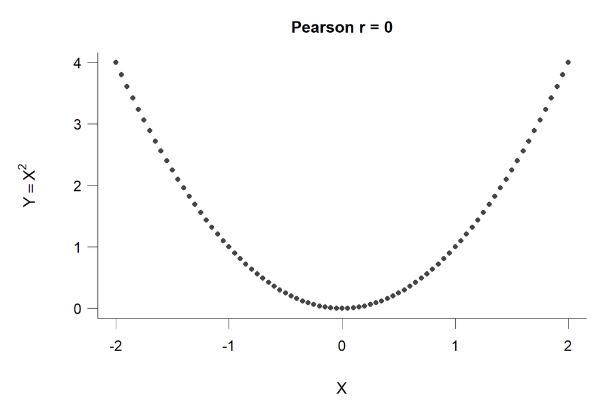

每個 X 只對應一個 Y；左右兩半的線性方向卻互相抵銷。

- X 在 −2 到 2 等距取 81 個值，Y = X²。
- 知道 X 就完全知道 Y，但左右兩半的乘積互相抵銷，r = 0。
- r = 0 只表示這批資料的線性摘要為零，不能推出獨立；樣本 r 也不等於母體相關係數。

Rosner 8e Example 11.27

## 相關不是因果

**Elmhurst**

- 收入與助學金負相關（r = −0.499）。
- 這是觀察資料：不能說「某位學生家庭收入增加，助學金就會減少」。

**母親與父親年齡**

- 正相關（r = 0.694）。
- 可能是選擇伴侶時年齡相近，也可能有其他共同因素；r 本身無法區分。

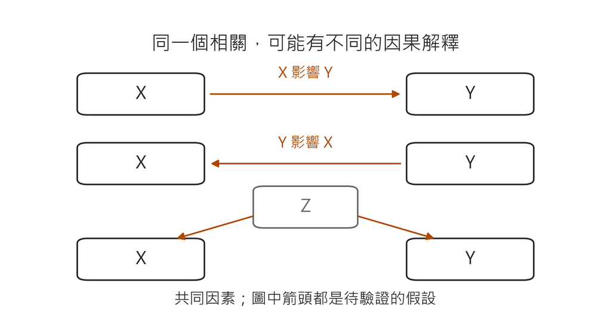

箭頭是待驗證的假設；只有相關係數，無法分辨圖中的因果解釋。

IMS 2e §7.2.3、§3.2；births14

## 練習 1｜三種操作，r 如何改變？

- 某資料的年齡與血壓 Pearson r = 0.6。先判斷，再說明理由：

| 操作 | r 改變嗎？ |
| --- | --- |
| 交換年齡與血壓 | ？ |
| 年齡由歲改成月 | ？ |
| 血壓改成「參考值 − 血壓」 | ？ |

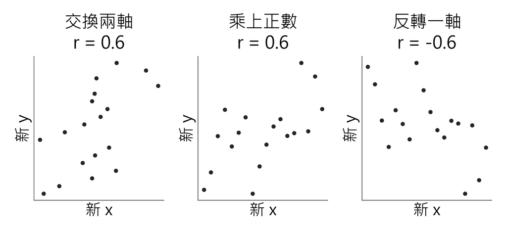

同一組自編資料的三種變換；點的配對保留，只有反轉一軸會改變 r 的正負。

- 依序為 **0.6、0.6、−0.6**：乘積可交換；正向換尺度保留 z 分數；反轉一軸使 z 分數變號。

IMS 2e §7.1.4

## 若關心大小次序：Spearman 等級相關

- Spearman 等級相關（Spearman rank correlation，r_s）是**等級的 Pearson 相關**。
1. x 由小到大排出等級 1, 2, …, n；y 也各自排序。
2. 同分值取平均等級。
3. 對兩組等級算 Pearson r。

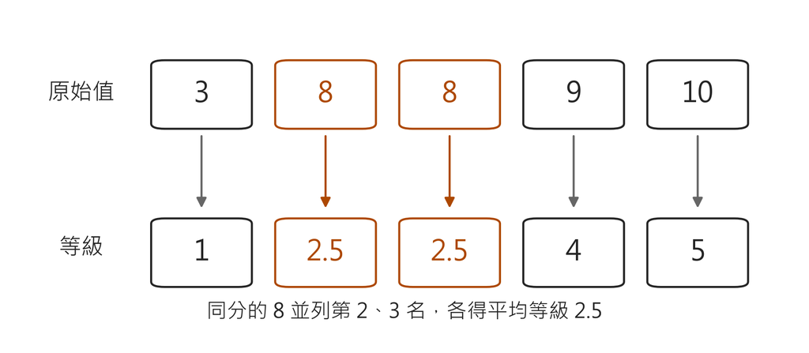

每個箭頭保留同一筆資料；兩個 8 同分，各給平均等級 2.5。

- 兩個 8 並列第 2、3 名，各得 (2 + 3)/2 = 2.5。
- r_s 保留次序，不看大多少。兩欄的等級仍逐筆配對，不能各自排好再重新拼接。

Rosner 8e §11.12，Definition 11.24

## 單調但彎曲

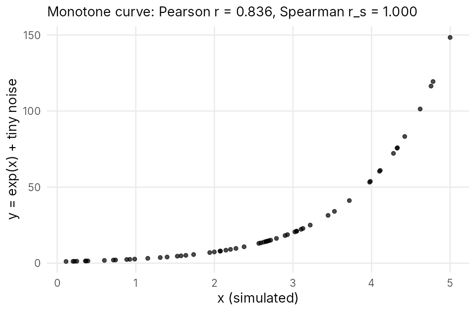

由左向右始終上升，但上升速度改變：單調不等於線性。

- 單調（monotonic）：一路上升或一路下降，不必是直線。本圖次序完全一致，r_s = 1；Pearson r = 0.836。

本課程

## Apgar 分數：1 分鐘與 5 分鐘

- Apgar 分數：心跳、呼吸、肌肉張力、反射、膚色，各 0–2 分，加總 0–10。
- 是次序資料。

| 新生兒 | 1 分鐘 | 5 分鐘 |
| --- | --- | --- |
| 1–12 | 10, 3, 8, 9, 8, 9, 8, 8, 8, 8, 7, 8 | 10, 6, 9, 10, 9, 10, 9, 9, 9, 9, 9, 9 |
| 13–24 | 6, 8, 9, 9, 9, 9, 8, 9, 3, 9, 7, 10 | 9, 10, 10, 10, 10, 9, 10, 9, 3, 9, 10, 10 |

Rosner 8e §11.12，Table 11.14–11.15、Example 11.58

## 原始分數與等級

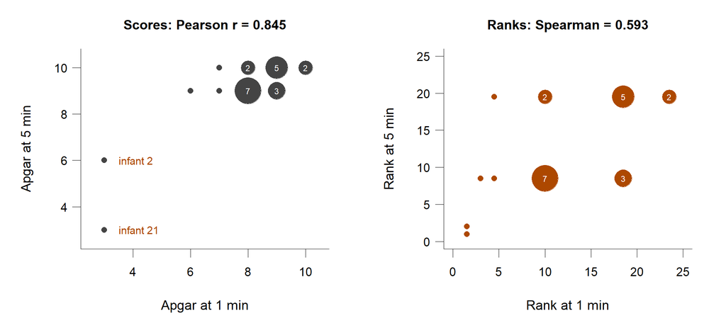

左為原始分數、右為等級；點內數字是同分人數，未標數字者為 1 人。

|  | Pearson r | Spearman r_s |
| --- | --- | --- |
| 估計值（95% CI） | 0.845（0.670, 0.931） | 0.593（0.327, 0.824） |

Rosner 8e Example 11.59、11.62，Table 11.15

## 兩名新生兒撐起 Pearson

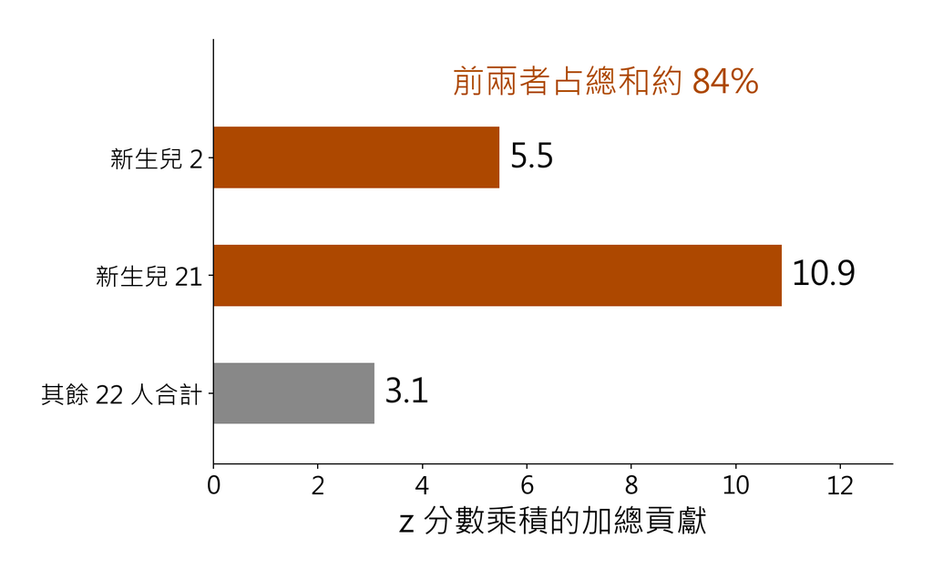

兩名低分者的乘積合計約占總和 84%；灰條是其餘 22 人的乘積加總。

- 新生兒 2（3, 6）與 21（3, 3）的 z 分數乘積約 5.5 與 10.9，占全部乘積總和的 **84%**。
- 5 分鐘只有 3、6、9、10 四種分數，同分很多。

| 排除新生兒 21 | Pearson | Spearman |
| --- | --- | --- |
| 前 | 0.845 | 0.593 |
| 後 | 0.788 | 0.527 |

- Spearman 也會變。它保留先後與同分結構，原始分數的極端距離不再被放大。

Rosner 8e Table 11.15

## 什麼時候用哪一個？

| 情況 | 較適合 |
| --- | --- |
| 數值資料、大致線性、沒有少數點主導 | Pearson |
| 次序資料，關心大小次序 | Spearman；同分取平均等級 |
| 單調但彎曲 | Spearman；形狀另用圖描述 |
| 少數極端點主導 | 兩者並列，加上有／無該點的比較 |
| 不單調（U 形） | 兩者都不適合，回到散布圖 |

- Pearson 保留原始數值的距離；Spearman 只比較次序。同分很多不代表一定要換方法，要先確定想描述哪種關係。

Rosner 8e §11.12；births14

## 練習 2｜單調、U 形，還是次序資料？

| 情境 | 選擇與理由 |
| --- | --- |
| 1–5 分疼痛與焦慮量表，想比較次序 | ？ |
| 數值資料一路上升，但明顯彎曲 | ？ |
| 數值資料呈對稱 U 形 | ？ |

- 依序：**Spearman** 描述次序；**Spearman＋圖形**描述單調曲線；**圖形為主**，兩種相關都可能接近零。
- Spearman 的高低不能代替形狀，也不會給出原始單位的平均預測。

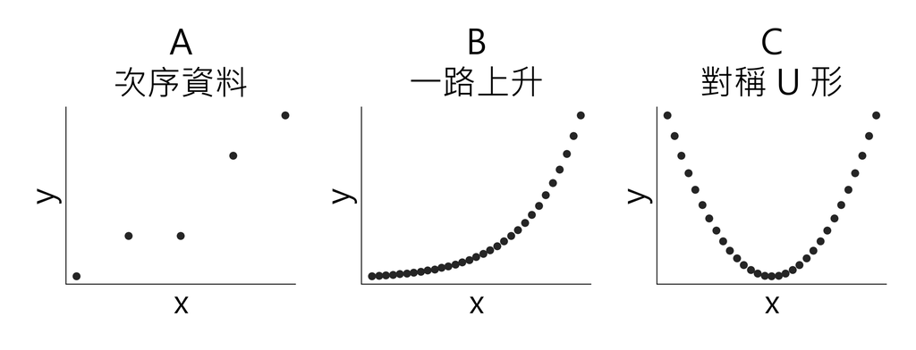

A–C 為三種情境的自編形狀示意，不是實際疼痛／焦慮資料；先判斷想保留什麼資訊。

Rosner 8e §11.12；IMS 2e §7.1.4

## 平均趨勢與個別差異

- 簡單線性迴歸（simple linear regression）用直線描述 y 的平均如何隨 x 改變。

$$y=\beta_0+\beta_1x+\varepsilon,\qquad \hat y=b_0+b_1x$$

| 符號 | 表示什麼？ |
| --- | --- |
| β₀、β₁ | 母體截距（intercept）與斜率（slope） |
| ε | 個別觀察值偏離母體直線的未知誤差（error） |
| b₀、b₁、ŷ | 樣本估計的係數與預測值；帽子表示估計 |

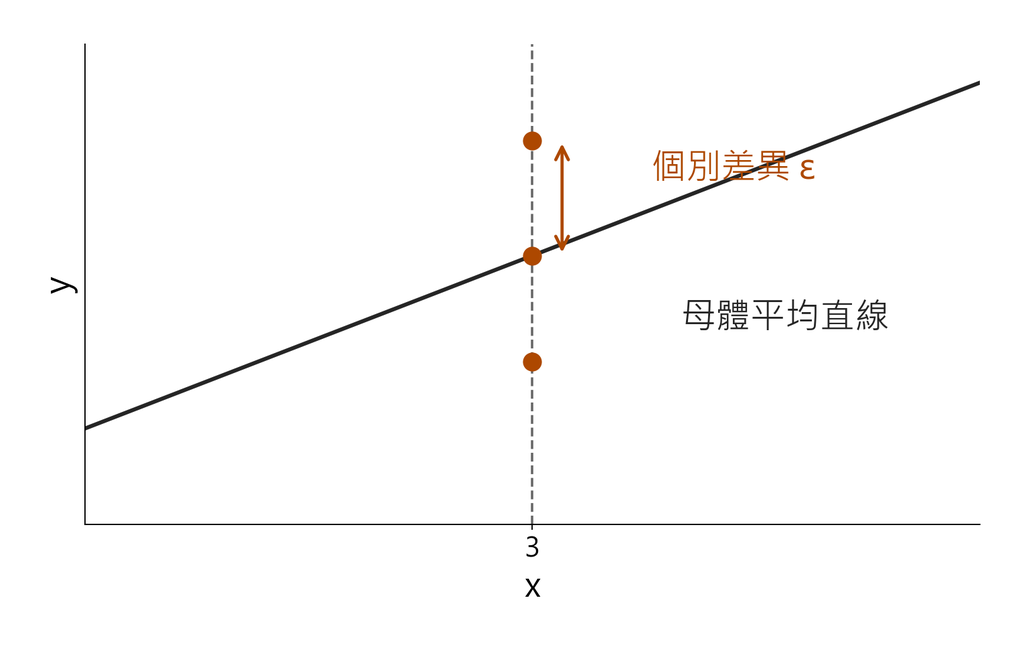

同一個 x 對應三個不同的 y；黑線為母體平均的示意，橘點表示個別差異。

- 同一個 x 可以對應不同的 y；平均預測不等於每個人的結果。

IMS 2e §7.1.1

## 殘差：觀察值減預測值

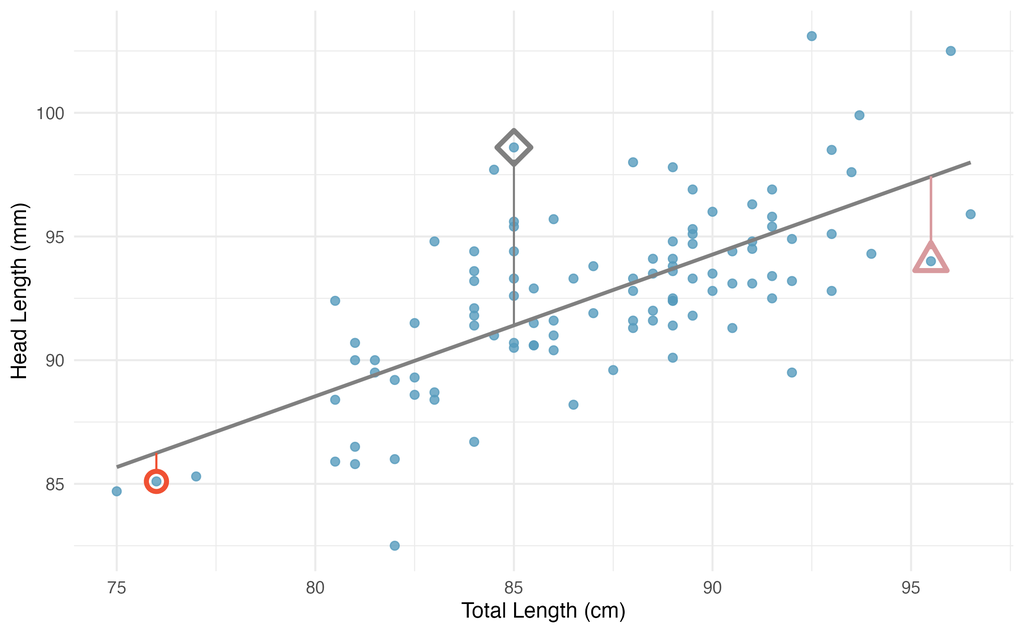

殘差沿縱軸量：點在直線上方為正、下方為負。

- 殘差（residual）$e_i = y_i - \hat y_i$。
- 固定 x，量沿 y 軸的差距；不是點到線的最短距離，也不是未知母體誤差 ε。
- 課本目測線 ŷ = 41 + 0.59x。總長 76.0 cm、頭長 85.1 mm：
- ŷ = 41 + 0.59 × 76.0 = 85.84 mm。
- e = 85.1 − 85.84 = **−0.74 mm**：模型高估 0.74 mm。

IMS 2e §7.1.1、§7.1.3，Figure 7.8（CC BY-SA）

## 練習｜由殘差還原觀察值

- 用一年中的晴天數，預測皮膚癌發生數（每 1,000 人）。某年的預測值為 1.5，殘差為 +0.5，兩者皆以每 1,000 人為單位。
1. 觀察值是多少？
2. 模型高估還是低估？差多少？

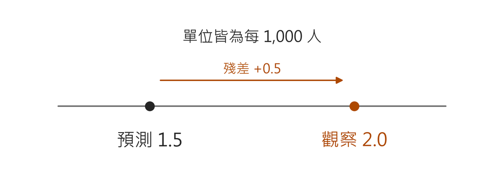

沿同一單位相加：預測值 1.5 加上殘差 +0.5，得到觀察值 2.0。

- 由 $e=y-\hat y$，得 $y=1.5+0.5=\mathbf{2.0}$（每 1,000 人）。
- 模型**低估 0.5**（每 1,000 人）。觀察值 = 預測值＋殘差，三者的單位要相同。

IMS 2e §7.5，Exercise 7.18（Over-under, II）

## 用什麼標準選出一條線？

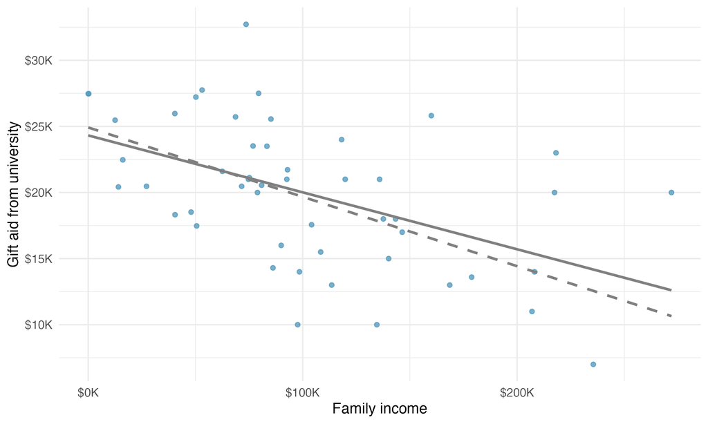

實線最小化殘差平方和，虛線最小化殘差絕對值和。

- 最小平方線（least squares line）讓殘差平方和（sum of squared errors，SSE）最小：

$\mathrm{SSE}=e_1^2 + e_2^2 + \cdots + e_n^2$

- 正負殘差直接相加，可能抵銷
- 平方保留每筆偏離，放大大殘差
- 後續係數、R² 與通常推論沿用此標準
- 這是指定資料中最佳的直線；趨勢彎曲時，仍不一定是好模型。

IMS 2e §7.2.2，Figure 7.14（CC BY-SA）

## 從摘要統計得到這條線

$$\begin{gathered}
\hat y = b_0 + b_1 x \\[4pt]
b_1 = r\,\frac{s_y}{s_x}, \qquad b_0 = \bar y - b_1 \bar x
\end{gathered}$$

|  | 平均 | SD |
| --- | --- | --- |
| 家庭收入 x（千美元） | 101.8 | 63.2 |
| 助學金 y（千美元） | 19.94 | 5.46 |

- r = −0.499 → $b_1 = -0.499 \times 5.46/63.2 = -0.0431$，$b_0 \approx 24.3$
- 斜率決定傾斜程度；直線通過平均點 $(\bar x,\bar y)$。因此 r 與斜率同號；平均殘差為 0 本身不能證明線性成立。

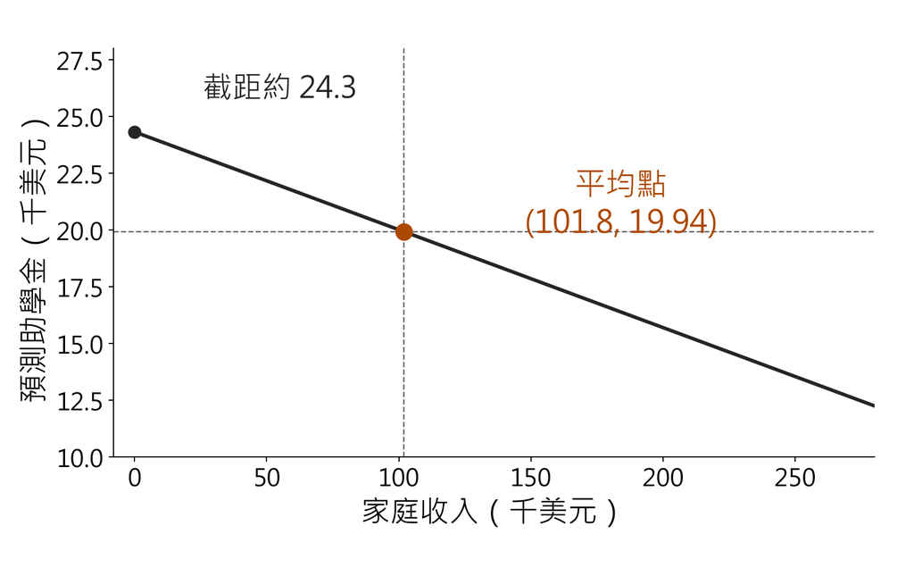

直線通過平均點 (101.8, 19.94)；圖只呈現由摘要算出的直線，沒有新增學生觀察值。

IMS 2e §7.2.3，Table 7.3

## 練習｜用 SD 推理，不先代入截距

- 由 $b_0=\bar y-b_1\bar x$ 得 $\hat y-\bar y=b_1(x-\bar x)$，所以

$$\frac{\hat y-\bar y}{s_y}=r\,\frac{x-\bar x}{s_x}
\qquad\Longrightarrow\qquad \hat z_y=r z_x$$

- 自編情境：r = 0.6，某人的 x 高於平均 2 個 SD。模型預測的 y 高於平均幾個 SD？

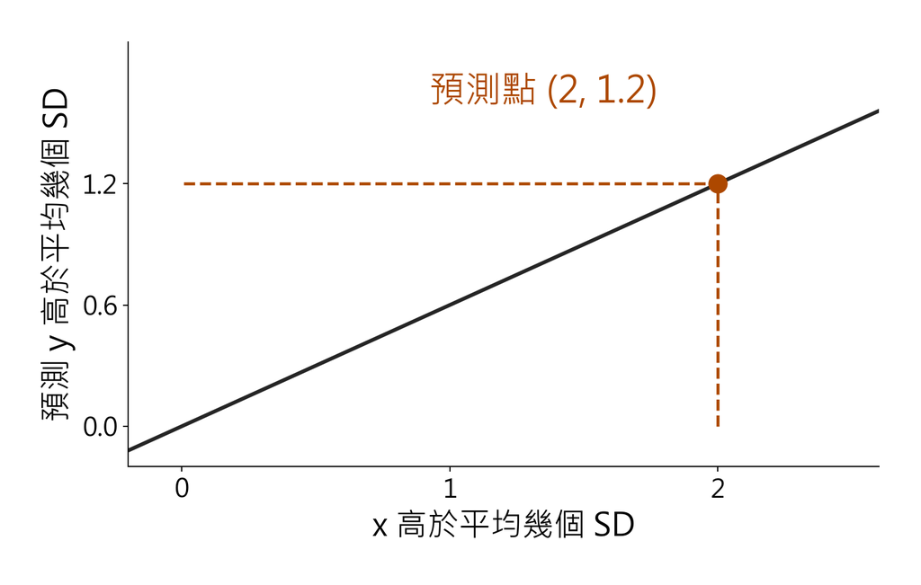

r = 0.6 時，x 高於平均 2 個 SD，平均預測 y 高於平均 1.2 個 SD。

- **1.2 個 SD**。預測平均比 x 更接近各自平均；不代表每個人的 y 都是這個值。

IMS 2e §7.2.3

## 解讀斜率與截距

- 預測助學金 = 24.3 − 0.0431 × 家庭收入（千美元）

| 係數 | 解讀 | 注意 |
| --- | --- | --- |
| 斜率 −0.0431 | 收入多 1 千美元，預測平均助學金少約 43 美元 | 比較不同學生，不是某人收入改變後的結果 |
| 截距 24.3 | 收入為 0 時的預測助學金 24.3 千美元 | 資料中有收入為 0 的學生，所以有意義 |

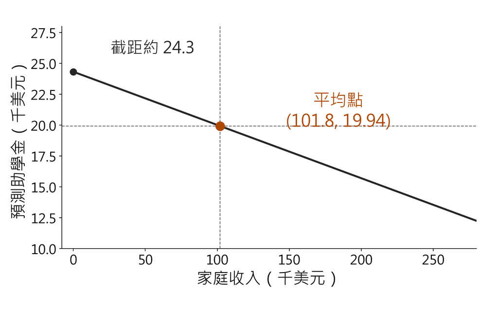

收入 0 對應截距；沿線往右走，預測助學金下降。兩軸仍保留千美元單位。

- 懷孕 0 週不在資料範圍內，因此截距 −3.6 磅只是延伸直線的計算結果，不能當成實際出生體重。

IMS 2e §7.2.3

## 外插

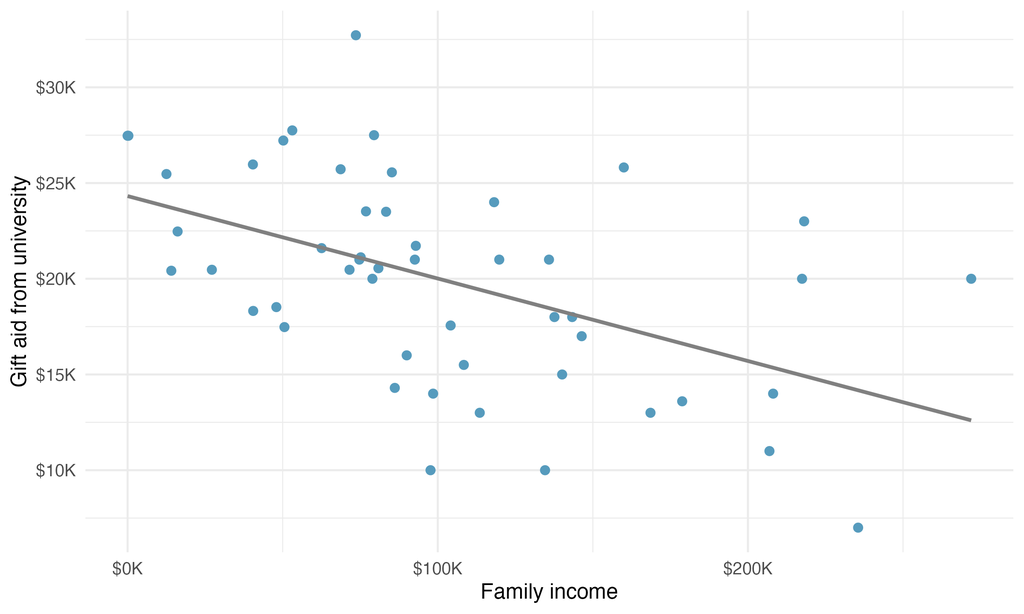

圖中家庭收入約 0–272 千美元；100 萬美元已超出此範圍。

- 家庭收入 100 萬美元（1,000 千美元）：
- 24.3 − 0.0431 × 1,000 ≈ **−18.8 千美元**
- 出現負的助學金預測，顯示不能把這條線直接延伸到此範圍。資料收入最高約 272 千美元。
- 超出資料範圍使用直線，稱為外插（extrapolation）。

IMS 2e §7.2.4，Figure 7.13（CC BY-SA）